# Prediction of Building Type From Satellite Imagery

## Removing outliers

```python
# Based on describe in step 5 we know the minimum values for two columns are
# impossible (large negative values for age and income). Step 1: decode
# how many values need to be replaced and the range of aberrant data
outlier_cols = ['median_age', 'median_household_income']
for col in outlier_cols:
    print(col)
    print(pbc_full_stats[col].quantile([0, 0.001, 0.005, 0.02, 0.03, 0.5, 1]))
    print()
```

```
median_age
0.00e+00   -6.67e+08
1.00e-03   -6.67e+08
5.00e-03    1.90e+01
2.00e-02    2.58e+01
3.00e-02    2.92e+01
5.00e-01    4.60e+01
1.00e+00    7.97e+01
Name: median_age, dtype: float64

median_household_income
0.00e+00   -6.67e+08
1.00e-03   -6.67e+08
5.00e-03   -6.67e+08
2.00e-02    2.53e+04
3.00e-02    2.63e+04
5.00e-01    7.09e+04
1.00e+00    1.99e+05
Name: median_household_income, dtype: float64
```

```python
for col in outlier_cols:
    pbc_full_stats.loc[pbc_full_stats[col] < 0, col] = np.nan

# impute the median value to avoid any outliers
imp_median = SimpleImputer(missing_values=np.nan, strategy='median')
imp_median.fit(pbc_full_stats[outlier_cols])
pbc_full_stats[outlier_cols] = imp_median.transform(pbc_full_stats[outlier_cols])

# confirm values all imputed, no longer outliers
print(pbc_full_stats[outlier_cols].isna().sum())
pbc_full_stats[outlier_cols].describe()
```

```
median_age                 0
median_household_income    0
dtype: int64
```

|  | median_age | median_household_income |
| --- | --- | --- |
| count | 8624.00 | 8624.00 |
| mean | 47.59 | 73968.10 |
| std | 11.78 | 31686.74 |
| min | 19.00 | 16855.00 |
| 25% | 39.30 | 46985.00 |
| 50% | 46.60 | 70888.00 |
| 75% | 58.10 | 98942.00 |
| max | 79.70 | 198625.00 |

```python
# for ordinary outliers that seem real, first take the log of the column
# to compress values onto a more normalized range

# create the log columns
log_cols = [x + '_log' for x in num_cols]
pbc_full_stats[log_cols] = pbc_full_stats[num_cols]


# take log of values
for col in log_cols:
    # eliminate any negative and zero values before taking log
    min_ = pbc_full_stats.loc[~(pbc_full_stats[col] <= 0)][col].min()
    pbc_full_stats.loc[pbc_full_stats[col] <= 0, col] = min_

    # apply log to make outliers less of a problem
    pbc_full_stats[col] = pbc_full_stats[col].apply(np.log)

pbc_full_stats[log_cols].describe()
```

|  | area_log | length_log | diagonal_log | n1_dist_log | n2_dist_log | n1_n4_area_std_log | n1_n6_area_std_log | n1_n9_area_std_log | n1_n4_len_std_log | n1_n6_len_std_log | n1_n9_len_std_log | n1_n4_diag_std_log | n1_n6_diag_std_log | n1_n9_diag_std_log | n1_n9_dist_sum_log | n1_n2_gap_log | n2_n3_gap_log | n1_n4_gap_prod_log | build_area_mean_log | pop_per_build_log |
| --- | --- | --- | --- | --- | --- | --- | --- | --- | --- | --- | --- | --- | --- | --- | --- | --- | --- | --- | --- | --- |
| count | 8624.00 | 8624.00 | 8624.00 | 8624.00 | 8624.00 | 8624.00 | 8624.00 | 8624.00 | 8624.00 | 8624.00 | 8624.00 | 8624.00 | 8624.00 | 8624.00 | 8624.00 | 8624.00 | 8624.00 | 8624.00 | 8624.00 | 8624.00 |
| mean | 6.21 | 4.59 | 3.62 | 3.41 | 3.64 | 5.23 | 5.40 | 5.55 | 3.12 | 3.26 | 3.38 | 2.22 | 2.36 | 2.45 | 6.38 | 1.56 | 2.33 | 5.39 | 6.29 | 1.17 |
| std | 0.90 | 0.53 | 0.53 | 0.54 | 0.59 | 0.98 | 0.89 | 0.84 | 0.86 | 0.75 | 0.68 | 0.78 | 0.68 | 0.61 | 0.46 | 1.30 | 1.04 | 1.86 | 0.36 | 0.50 |
| min | 4.09 | 3.43 | 2.30 | 2.40 | 2.56 | 1.49 | 2.39 | 2.37 | -0.69 | 0.28 | 0.50 | -0.69 | 0.03 | 0.45 | 5.58 | 0.00 | 0.00 | 0.00 | 5.30 | -0.04 |
| 25% | 5.65 | 4.26 | 3.30 | 3.00 | 3.22 | 4.60 | 4.82 | 5.02 | 2.57 | 2.78 | 2.95 | 1.72 | 1.90 | 2.05 | 6.05 | 0.00 | 1.95 | 4.09 | 6.03 | 0.85 |
| 50% | 6.01 | 4.47 | 3.50 | 3.30 | 3.56 | 5.21 | 5.37 | 5.51 | 3.12 | 3.26 | 3.36 | 2.22 | 2.34 | 2.44 | 6.28 | 1.61 | 2.64 | 5.26 | 6.28 | 1.16 |
| 75% | 6.53 | 4.76 | 3.83 | 3.71 | 4.03 | 5.82 | 5.90 | 5.99 | 3.67 | 3.72 | 3.77 | 2.73 | 2.79 | 2.81 | 6.62 | 2.71 | 3.00 | 6.45 | 6.39 | 1.41 |
| max | 11.50 | 7.76 | 6.62 | 6.51 | 6.58 | 10.66 | 10.46 | 10.26 | 6.77 | 6.57 | 6.36 | 5.58 | 5.39 | 5.19 | 9.90 | 4.61 | 4.61 | 13.77 | 8.03 | 4.05 |

```python
num_col_all = log_cols + no_log_num
norm_cols = [x + '_norm' for x in num_col_all]
pbc_full_stats[norm_cols] = pbc_full_stats[num_col_all]
```

```python
# get mean and std for each column
stats = pbc_full_stats[norm_cols].describe()

for col in norm_cols:
    mean = stats.loc['mean', col]
    std = stats.loc['std', col]

    # trim train data
    pbc_full_stats.loc[(pbc_full_stats[col] > (mean + 3.5*std)), col] = mean + 3.5*std
    pbc_full_stats.loc[(pbc_full_stats[col] < (mean - 3.5*std)), col] = mean - 3.5*std
```

## 13. One-hot encoding

```python
# one hot encode neighbor building spacing pattern and sides
onehoter = OneHotEncoder(sparse = False, drop = "first")
onehoter.fit(pbc_full_stats[cat_cols])
onehot_cols = onehoter.get_feature_names(cat_cols)
pbc_onehot = pd.DataFrame(onehoter.transform(pbc_full_stats[cat_cols]), columns = onehot_cols)
pbc_onehot
```

|  | distance_pattern_3_001 | distance_pattern_3_010 | distance_pattern_3_011 | distance_pattern_3_100 | distance_pattern_3_101 | distance_pattern_3_110 | distance_pattern_3_111 | sides_cat_5_6 | sides_cat_7_9 | sides_cat_gt_9 | is_coastal_1 |
| --- | --- | --- | --- | --- | --- | --- | --- | --- | --- | --- | --- |
| 0 | 0.0 | 0.0 | 0.0 | 1.0 | 0.0 | 0.0 | 0.0 | 1.0 | 0.0 | 0.0 | 0.0 |
| 1 | 0.0 | 0.0 | 0.0 | 0.0 | 0.0 | 0.0 | 1.0 | 1.0 | 0.0 | 0.0 | 0.0 |
| 2 | 0.0 | 0.0 | 1.0 | 0.0 | 0.0 | 0.0 | 0.0 | 0.0 | 0.0 | 0.0 | 0.0 |
| 3 | 0.0 | 0.0 | 0.0 | 0.0 | 0.0 | 1.0 | 0.0 | 0.0 | 0.0 | 0.0 | 0.0 |
| 4 | 0.0 | 1.0 | 0.0 | 0.0 | 0.0 | 0.0 | 0.0 | 1.0 | 0.0 | 0.0 | 0.0 |
| ... | ... | ... | ... | ... | ... | ... | ... | ... | ... | ... | ... |
| 8619 | 0.0 | 0.0 | 0.0 | 0.0 | 0.0 | 0.0 | 1.0 | 0.0 | 0.0 | 1.0 | 0.0 |
| 8620 | 0.0 | 1.0 | 0.0 | 0.0 | 0.0 | 0.0 | 0.0 | 0.0 | 0.0 | 1.0 | 0.0 |
| 8621 | 0.0 | 0.0 | 0.0 | 0.0 | 0.0 | 0.0 | 1.0 | 0.0 | 0.0 | 0.0 | 1.0 |
| 8622 | 0.0 | 0.0 | 0.0 | 1.0 | 0.0 | 0.0 | 0.0 | 0.0 | 0.0 | 1.0 | 1.0 |
| 8623 | 0.0 | 0.0 | 0.0 | 0.0 | 0.0 | 0.0 | 1.0 | 0.0 | 0.0 | 0.0 | 0.0 |

8624 rows × 11 columns

## Preparation of Data Set: 14. Normalization

## Unsupervised Learning: 3. Normalize the attributes prior to K-Means

```python
# min max scale the columns
minmax_scaler = MinMaxScaler()
minmax_scaler.fit(pbc_full_stats[norm_cols])
pbc_full_stats_norm = pd.DataFrame(minmax_scaler.transform(pbc_full_stats[norm_cols]), columns=norm_cols)
pbc_full_stats_norm
```

|  | area_log_norm | length_log_norm | diagonal_log_norm | n1_dist_log_norm | n2_dist_log_norm | n1_n4_area_std_log_norm | n1_n6_area_std_log_norm | n1_n9_area_std_log_norm | n1_n4_len_std_log_norm | n1_n6_len_std_log_norm | n1_n9_len_std_log_norm | n1_n4_diag_std_log_norm | n1_n6_diag_std_log_norm | n1_n9_diag_std_log_norm | n1_n9_dist_sum_log_norm | n1_n2_gap_log_norm | n2_n3_gap_log_norm | n1_n4_gap_prod_log_norm | build_area_mean_log_norm | pop_per_build_log_norm | step_count_weighted_norm | median_age_norm | pct_child_norm | pct_uni_norm | pct_senior_norm | median_household_income_norm | low_income_pct_norm | pct_homeowner_norm | pct_white_norm | … |
| --- | --- | --- | --- | --- | --- | --- | --- | --- | --- | --- | --- | --- | --- | --- | --- | --- | --- | --- | --- | --- | --- | --- | --- | --- | --- | --- | --- | --- | --- | --- |
| 0 | 0.72 | 0.69 | 0.73 | 0.72 | 0.64 | 0.64 | 0.58 | 0.55 | 0.71 | 0.66 | 0.63 | 0.68 | 0.63 | 0.59 | 0.51 | 0.39 | 0.00 | 0.15 | 0.41 | 0.33 | 0.48 | 0.51 | 0.60 | 0.15 | 0.21 | 0.68 | 0.08 | 0.96 | 0.91 | … |
| 1 | 0.35 | 0.33 | 0.35 | 0.50 | 0.55 | 0.54 | 0.48 | 0.50 | 0.54 | 0.49 | 0.53 | 0.55 | 0.50 | 0.53 | 0.61 | 0.72 | 0.68 | 0.83 | 0.41 | 0.33 | 0.88 | 0.51 | 0.60 | 0.15 | 0.21 | 0.68 | 0.08 | 0.96 | 0.91 | … |
| 2 | 0.28 | 0.25 | 0.28 | 0.13 | 0.09 | 0.67 | 0.63 | 0.59 | 0.63 | 0.60 | 0.55 | 0.65 | 0.61 | 0.56 | 0.17 | 0.00 | 0.60 | 0.49 | 0.30 | 0.51 | 0.35 | 0.36 | 0.57 | 0.18 | 0.14 | 0.28 | 0.26 | 0.72 | 0.67 | … |
| 3 | 0.17 | 0.16 | 0.19 | 0.15 | 0.37 | 0.48 | 0.40 | 0.36 | 0.53 | 0.46 | 0.40 | 0.56 | 0.49 | 0.41 | 0.23 | 0.70 | 0.50 | 0.46 | 0.30 | 0.51 | 0.55 | 0.36 | 0.57 | 0.18 | 0.14 | 0.28 | 0.26 | 0.72 | 0.67 | … |
| 4 | 0.36 | 0.33 | 0.41 | 0.35 | 0.30 | 0.50 | 0.42 | 0.39 | 0.51 | 0.43 | 0.39 | 0.51 | 0.42 | 0.38 | 0.25 | 0.24 | 0.67 | 0.35 | 0.30 | 0.51 | 0.24 | 0.36 | 0.57 | 0.18 | 0.14 | 0.28 | 0.26 | 0.72 | 0.67 | … |
| ... | ... | ... | ... | ... | ... | ... | ... | ... | ... | ... | ... | ... | ... | ... | ... | ... | ... | ... | ... | ... | ... | ... | ... | ... | ... | ... | ... | ... | ... | … |
| 8619 | 0.82 | 0.92 | 0.89 | 0.48 | 0.51 | 0.39 | 0.36 | 0.62 | 0.40 | 0.38 | 0.65 | 0.37 | 0.35 | 0.74 | 0.75 | 0.66 | 0.83 | 0.83 | 0.98 | 1.00 | 0.86 | 0.92 | 0.06 | 0.02 | 0.87 | 0.08 | 0.46 | 0.74 | 0.81 | … |
| 8620 | 0.76 | 0.99 | 0.89 | 0.65 | 0.56 | 0.31 | 0.30 | 0.37 | 0.30 | 0.36 | 0.38 | 0.25 | 0.36 | 0.35 | 0.57 | 0.15 | 0.60 | 0.43 | 0.98 | 1.00 | 0.46 | 0.92 | 0.06 | 0.02 | 0.87 | 0.08 | 0.46 | 0.74 | 0.81 | … |
| 8621 | 0.49 | 0.47 | 0.51 | 0.47 | 0.43 | 0.26 | 0.34 | 0.28 | 0.17 | 0.37 | 0.28 | 0.29 | 0.28 | 0.19 | 0.38 | 0.42 | 0.39 | 0.58 | 0.59 | 0.71 | 0.86 | 0.83 | 0.02 | 0.04 | 0.75 | 0.53 | 0.08 | 0.85 | 0.93 | … |
| 8622 | 0.72 | 0.67 | 0.71 | 0.81 | 0.76 | 0.42 | 0.36 | 0.32 | 0.41 | 0.36 | 0.32 | 0.50 | 0.42 | 0.35 | 0.76 | 0.71 | 0.00 | 0.27 | 0.59 | 0.71 | 0.63 | 0.83 | 0.02 | 0.04 | 0.75 | 0.53 | 0.08 | 0.85 | 0.93 | … |
| 8623 | 0.39 | 0.34 | 0.44 | 1.00 | 1.00 | 0.65 | 0.61 | 0.57 | 0.66 | 0.63 | 0.58 | 0.60 | 0.59 | 0.53 | 1.00 | 0.70 | 0.72 | 0.94 | 0.54 | 0.00 | 1.00 | 0.45 | 0.48 | 0.12 | 0.23 | 0.32 | 0.19 | 0.77 | 0.70 | … |

8624 rows × 34 columns

# Unsupervised Learning

## Perform a K-Means grouping on building attributes

including the tract level data will just cluster by tract, so will cluster purely by building data

```python
#select relevent columns to cluster, inculding a categorical and several numerical
sides_hot = ['sides_cat_5_6', 'sides_cat_7_9', 'sides_cat_gt_9']
build_cols = ['area_log_norm', 'length_log_norm', 'diagonal_log_norm',
       'n1_dist_log_norm', 'n2_dist_log_norm', 'n1_n4_area_std_log_norm',
       'n1_n6_area_std_log_norm', 'n1_n9_area_std_log_norm',
       'n1_n4_len_std_log_norm', 'n1_n6_len_std_log_norm',
       'n1_n9_len_std_log_norm', 'n1_n4_diag_std_log_norm',
       'n1_n6_diag_std_log_norm', 'n1_n9_diag_std_log_norm',
       'n1_n9_dist_sum_log_norm', 'n1_n2_gap_log_norm', 'n2_n3_gap_log_norm',
       'n1_n4_gap_prod_log_norm', 'step_count_weighted_norm' ]
kmeans_df = pbc_onehot[sides_hot].join(pbc_full_stats_norm[build_cols])
```

```python
kmeans_df.describe()
```

|  | sides_cat_5_6 | sides_cat_7_9 | sides_cat_gt_9 | area_log_norm | length_log_norm | diagonal_log_norm | n1_dist_log_norm | n2_dist_log_norm | n1_n4_area_std_log_norm | n1_n6_area_std_log_norm | n1_n9_area_std_log_norm | n1_n4_len_std_log_norm | n1_n6_len_std_log_norm | n1_n9_len_std_log_norm | n1_n4_diag_std_log_norm | n1_n6_diag_std_log_norm | n1_n9_diag_std_log_norm | n1_n9_dist_sum_log_norm | n1_n2_gap_log_norm | n2_n3_gap_log_norm | n1_n4_gap_prod_log_norm | step_count_weighted_norm |
| --- | --- | --- | --- | --- | --- | --- | --- | --- | --- | --- | --- | --- | --- | --- | --- | --- | --- | --- | --- | --- | --- | --- |
| count | 8624.00 | 8624.00 | 8624.00 | 8624.00 | 8624.00 | 8624.00 | 8624.00 | 8624.00 | 8624.00 | 8624.00 | 8624.00 | 8624.00 | 8624.00 | 8624.00 | 8624.00 | 8624.00 | 8624.00 | 8624.00 | 8624.00 | 8624.00 | 8624.00 | 8624.00 |
| mean | 0.27 | 0.14 | 0.15 | 0.40 | 0.38 | 0.41 | 0.35 | 0.34 | 0.50 | 0.49 | 0.50 | 0.50 | 0.50 | 0.50 | 0.50 | 0.49 | 0.48 | 0.33 | 0.34 | 0.51 | 0.45 | 0.53 |
| std | 0.44 | 0.35 | 0.35 | 0.17 | 0.17 | 0.16 | 0.18 | 0.19 | 0.14 | 0.14 | 0.14 | 0.14 | 0.14 | 0.14 | 0.14 | 0.14 | 0.15 | 0.19 | 0.28 | 0.23 | 0.16 | 0.21 |
| min | 0.00 | 0.00 | 0.00 | 0.00 | 0.00 | 0.00 | 0.00 | 0.00 | 0.00 | 0.00 | 0.00 | 0.00 | 0.00 | 0.00 | 0.00 | 0.00 | 0.00 | 0.00 | 0.00 | 0.00 | 0.00 | 0.00 |
| 25% | 0.00 | 0.00 | 0.00 | 0.30 | 0.27 | 0.31 | 0.21 | 0.21 | 0.41 | 0.40 | 0.41 | 0.41 | 0.41 | 0.41 | 0.41 | 0.40 | 0.39 | 0.20 | 0.00 | 0.42 | 0.34 | 0.34 |
| 50% | 0.00 | 0.00 | 0.00 | 0.37 | 0.34 | 0.38 | 0.31 | 0.32 | 0.50 | 0.49 | 0.49 | 0.50 | 0.50 | 0.50 | 0.50 | 0.49 | 0.48 | 0.29 | 0.35 | 0.57 | 0.44 | 0.49 |
| 75% | 1.00 | 0.00 | 0.00 | 0.46 | 0.44 | 0.48 | 0.45 | 0.47 | 0.59 | 0.57 | 0.58 | 0.59 | 0.59 | 0.58 | 0.59 | 0.59 | 0.57 | 0.43 | 0.59 | 0.65 | 0.54 | 0.72 |
| max | 1.00 | 1.00 | 1.00 | 1.00 | 1.00 | 1.00 | 1.00 | 1.00 | 1.00 | 1.00 | 1.00 | 1.00 | 1.00 | 1.00 | 1.00 | 1.00 | 1.00 | 1.00 | 1.00 | 1.00 | 1.00 | 1.00 |

```python
# set number of clusters, will use two to match the number of categories
# will try to predict in supervised learning
n_clusters = 2

# get the model
kmeans = KMeans(n_clusters = n_clusters, random_state = 42)

# fit the clusters
kmeans.fit(kmeans_df)
```

```
KMeans(n_clusters=2, random_state=42)
```

## Add the cluster label to the data set to be used in supervised learning

```python
# add cluster label to main data set
pbc_full_stats['cluster'] = kmeans.predict(kmeans_df)
pbc_full_stats['cluster'].value_counts(dropna=False)
```

```
0    6292
1    2332
Name: cluster, dtype: int64
```

```python
# compare unsupervised clustering to target, see if unsupervised detects the difference
pbc_full_stats.groupby(['cluster', 'label'])['id'].count().unstack()
```

| label cluster | Commercial | Residential |
| --- | --- | --- |
| 0 | 1306 | 4986 |
| 1 | 160 | 2172 |

# Supervised Learning

Can facts about the geometry of a building's footprint as determined by algorithmic scraping of satellite imagery, when combined with facts about the neighborhood from the Census Department, allow you to predict if the building is used for commercial or residential purposes, as labeled by OpenStreetMaps volunteers?

## Split data set into training and testing sets

```python
cat_cols_all = ['distance_pattern_3', 'sides_cat', 'is_coastal', 'cluster']
cols_for_ml = num_col_all + cat_cols_all

X_train, X_test, y_train, y_test = train_test_split(pbc_full_stats[cols_for_ml],
                                                    pbc_full_stats['label'],
                                                    test_size = 0.2, random_state = 42)
```

```python
# get mean and std for each column
stats = X_train.describe()

for col in num_col_all:
    mean = stats.loc['mean', col]
    std = stats.loc['std', col]

    # trim train data
    X_train.loc[(X_train[col] > (mean + 3.5*std)), col] = mean + 3.5*std
    X_train.loc[(X_train[col] < (mean - 3.5*std)), col] = mean - 3.5*std

    # trim test using mean and std of train data
    X_test.loc[(X_test[col] > (mean + 3.5*std)), col] = mean + 3.5*std
    X_test.loc[(X_test[col] < (mean - 3.5*std)), col] = mean - 3.5*std
```

```python
# min max scale the columns
minmax_scaler = MinMaxScaler()
minmax_scaler.fit(X_train[num_col_all])
X_train_norm = pd.DataFrame(minmax_scaler.transform(X_train[num_col_all]), columns=num_col_all)
X_test_norm = pd.DataFrame(minmax_scaler.transform(X_test[num_col_all]), columns=num_col_all)
```

```python
# one hot encode categorical
onehoter = OneHotEncoder(sparse = False, drop = "first")
onehoter.fit(X_train[cat_cols_all])
onehot_cols = onehoter.get_feature_names(cat_cols_all)
X_train_onehot = pd.DataFrame(onehoter.transform(X_train[cat_cols_all]), columns = onehot_cols)
X_test_onehot = pd.DataFrame(onehoter.transform(X_test[cat_cols_all]), columns = onehot_cols)
```

```python
# combine categorical and numerical data columns
X_train_featurized = X_train_onehot # add one-hot-encoded columns
X_test_featurized = X_test_onehot   # add one-hot-encoded columns
X_train_featurized[num_col_all] = X_train_norm # add numeric columns
X_test_featurized[num_col_all] = X_test_norm   # add numeric columns

del X_train_norm, X_test_norm, X_train_onehot, X_test_onehot

print("Featurized training data has {} rows and {} columns.".format(*X_train_featurized.shape))
print("Featurized test data has {} rows and {} columns.".format(*X_test_featurized.shape))
```

```
Featurized training data has 6899 rows and 46 columns.
Featurized test data has 1725 rows and 46 columns.
```

## Train classifiers on the training set and apply to the test set.

```python
# model with decision tree classifier
dtree = DecisionTreeClassifier(max_depth = 7, random_state=42)
dtree.fit(X_train_featurized, y_train)

y_hat_train = dtree.predict(X_train_featurized)
y_hat_test_dtree = dtree.predict(X_test_featurized)
y_hat_proba_dtree = dtree.predict_proba(X_test_featurized)
```

```python
# Try LogisticRegression classifier

logit = LogisticRegression(max_iter = 3000, solver='lbfgs', penalty= 'none', random_state=42,)
logit.fit(X_train_featurized, y_train)

y_hat_train = logit.predict(X_train_featurized)
y_hat_test = logit.predict(X_test_featurized)
y_hat_proba_logit = logit.predict_proba(X_test_featurized)
```

## Create and present a confusion matrix for each classifier.

DecisionTree threshold determination, confusion matrix and 2 accuracy metrics based on the confusion matrix of the classifier.

```python
# test a range of thresholds to find the optimal one
for thresh_val in [x/100 for x in range(10,60,5)]:
    # set every probability over the threshhold to 1 (True)
    thresh = y_hat_proba_dtree[:,0] > thresh_val
    thresh = thresh.astype(int)

    # convert 1 to Commercial, and 0 to Residential to match target
    thresh = np.where(thresh==1, "Commercial", thresh)
    thresh = np.where(thresh=='0', "Residential", thresh)

    # output F1 score to determine the best level for the threshold
    f1_thresh = f1_score(y_test, thresh, pos_label = 'Commercial') * 100
    print(f"Threshold of {thresh_val}:\tF1 score = {f1_thresh:.0f}%")
```

```
Threshold of 0.1:	F1 score = 80%
Threshold of 0.15:	F1 score = 81%
Threshold of 0.2:	F1 score = 81%
Threshold of 0.25:	F1 score = 82%
Threshold of 0.3:	F1 score = 82%
Threshold of 0.35:	F1 score = 82%
Threshold of 0.4:	F1 score = 83%
Threshold of 0.45:	F1 score = 83%
Threshold of 0.5:	F1 score = 83%
Threshold of 0.55:	F1 score = 82%
```

```python
# best threshold seems to be at .45 based on peak F1 score
best_thresh_val = .45
best_thresh = y_hat_proba_dtree[:,0] > best_thresh_val
best_thresh = best_thresh.astype(int)
best_thresh = np.where(best_thresh==1, "Commercial", best_thresh)
best_thresh = np.where(best_thresh=='0', "Residential", best_thresh)

# confusion matrix
confusion = confusion_matrix(y_test, best_thresh)
confusion
```

```
array([[ 230,   53],
       [  42, 1400]])
```

```python
# calculate precision and recall from the confusion matrix
precision_test = confusion[0][0] / (confusion[0][0] + confusion[1][0])
recall_test = confusion[0][0] / (confusion[0][0] + confusion[0][1])
accuracy_test = (confusion[0][0] + confusion[1][1]) / \
    (confusion[0][0] + confusion[0][1] + + confusion[1][1] + confusion[1][0])

print(f'With a threshhold of {best_thresh_val} the model achieves a')
print(f'precision in predicting commercial buildings of {precision_test*100:.0f}%')
print(f'and a recall score of {recall_test*100:.0f}%. Overall accuracy was {accuracy_test*100:.0f}%.')
```

```
With a threshhold of 0.45 the model achieves a
precision in predicting commercial buildings of 85%
and a recall score of 81%. Overall accuracy was 94%.
```

LogisticRegression threshold determination, confusion matrix and 2 accuracy metrics based on the confusion matrix of the classifier.

```python
# test a range of thresholds to find the optimal one
for thresh_val in [x/100 for x in range(10,60,5)]:
    # set every probability over the threshhold to 1 (True)
    thresh = y_hat_proba_logit[:,0] > thresh_val
    thresh = thresh.astype(int)

    # convert 1 to Commercial, and 0 to Residential to match target
    thresh = np.where(thresh==1, "Commercial", thresh)
    thresh = np.where(thresh=='0', "Residential", thresh)

    # output F1 score to determine the best level for the threshold
    f1_thresh = f1_score(y_test, thresh, pos_label = 'Commercial') * 100
    print(f"Threshold of {thresh_val}:\tF1 score = {f1_thresh:.0f}%")
```

```
Threshold of 0.1:	F1 score = 63%
Threshold of 0.15:	F1 score = 68%
Threshold of 0.2:	F1 score = 71%
Threshold of 0.25:	F1 score = 72%
Threshold of 0.3:	F1 score = 72%
Threshold of 0.35:	F1 score = 72%
Threshold of 0.4:	F1 score = 72%
Threshold of 0.45:	F1 score = 72%
Threshold of 0.5:	F1 score = 70%
Threshold of 0.55:	F1 score = 70%
```

```python
# best threshold seems to be at .35 based on peak F1 score
best_thresh_val = .35
best_thresh = y_hat_proba_logit[:,0] > best_thresh_val
best_thresh = best_thresh.astype(int)
best_thresh = np.where(best_thresh==1, "Commercial", best_thresh)
best_thresh = np.where(best_thresh=='0', "Residential", best_thresh)

# confusion matrix
confusion = confusion_matrix(y_test, best_thresh)
confusion
```

```
array([[ 206,   77],
       [  85, 1357]])
```

```python
# calculate precision and recall from the confusion matrix
precision_test = confusion[0][0] / (confusion[0][0] + confusion[1][0])
recall_test = confusion[0][0] / (confusion[0][0] + confusion[0][1])
accuracy_test = (confusion[0][0] + confusion[1][1]) / \
    (confusion[0][0] + confusion[0][1] + + confusion[1][1] + confusion[1][0])

print(f'With a threshhold of {best_thresh_val} the model achieves a')
print(f'precision in predicting commercial buildings of {precision_test*100:.0f}%')
print(f'and a recall score of {recall_test*100:.0f}%. Overall accuracy was {accuracy_test*100:.0f}%.')
```

```
With a threshhold of 0.35 the model achieves a
precision in predicting commercial buildings of 71%
and a recall score of 73%. Overall accuracy was 91%.
```

## Calculate the ROC curve and it's AUC

```python
# plotting function borrowed from course materials
def plot_roc(models, model_names):
    plt.figure(0, figsize = [8, 7]).clf()
    plt.plot([0, 1], [0, 1],'r--')
    plt.xlim([0, 1])
    plt.ylim([0, 1])
    plt.ylabel('True Positive Rate')
    plt.xlabel('False Positive Rate')

    for ii, model in enumerate(models):
        y_prob_test = model.predict_proba(X_test_featurized)[:, 0]
        fpr, tpr, threshold = roc_curve(y_test, y_prob_test, pos_label = "Commercial")
        roc_auc = auc(fpr, tpr)
        plt.plot(fpr, tpr, label = "{} AUC = {:0.2f}".format(model_names[ii], roc_auc))

    plt.legend(loc = 'lower right');
```

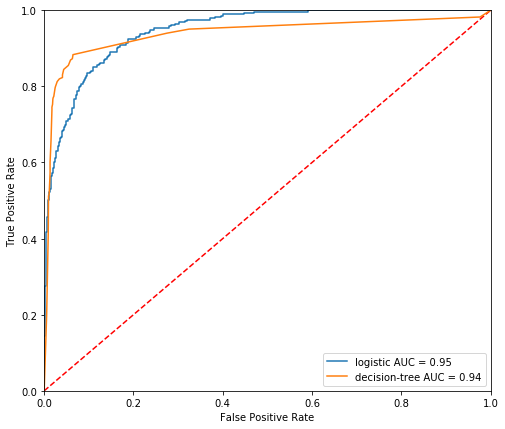

```python
# plot the models against each other
plot_roc([logit, dtree], ['logistic', 'decision-tree'])
```